# 7_3_ESmoothing_Trended

```r
library(fpp3)
```

# References

1. Hyndman, R.J., & Athanasopoulos, G., 2021. *Forecasting: principles and practice*. 3rd edition.
2. Fable package documentation
- https://fable.tidyverts.org/index.html
- https://fable.tidyverts.org/articles/fable.html

# Note

This notebook is not original material, but rather based on ref. 1 with notes expanding on some of the concepts contained in the book.

# **Motivation**

So far we have seen **Simple Exponential Smoothing**, a forecasting model that lied in between the Mean and the Naive models:

- The **naive** model assigned **a constant value to all future forecasts**, the **last observation**. It assigns all the weight to the latest observation
- The **mean** model **assigned a constant value to all future forecasts** with an **equal weight for each observation regardless of when it occurred****.**
- **Simple Exponential Smoothing** also assigns a **constant value to all future forecast**, but this value is a weighted average that assigns the bigger weights to the most recent observations. The further in the past an observation lies, the smaller its assigned weight.

We now want to **introduce trend and seasonality in exponential smoothing**

Let us first recall the component form of simple exponential smoothing:

$$\begin{align*}
\text{Forecast equation} && \hat{y}_{t+h|t} & = \ell_{t}\\
\text{Smoothing equation} && \ell_{t} & = \alpha y_{t} + (1 - \alpha)\ell_{t-1},
\end{align*}$$

- $l_t$ is the level (or the smoothed value) of the series at time $t$
- $h = 1$ gives the fitted values
- $t = T$ gives the true forecasts beyond the training data

**Forecast equation**

- The forecast at *t+1* is the *estimated level at time t*.

**Smoothing equation**

- The *smoothing equation* gives the *estimated level of the series at each period t*.

**Flat forecasts**

- SES has a flat forecast function –> all forecasts take the same value, equal to the last level component.

$$\begin{align*}
\hat{y}_{T+h|T} = \hat{y}_{T+1|T}= l_T \qquad h=2,3,\dots.
\end{align*}$$

# Holt’s Linear Trend Method

Holt extended Simple Exponential Smoothing to allow the forecasting of data with trend.

$$\begin{align*}
\text{Forecast equation}&& \hat{y}_{t+h|t} &= \ell_{t} + hb_{t} \\
\text{Level equation} && \ell_{t} &= \alpha y_{t} + (1 - \alpha)(\ell_{t-1} + b_{t-1})\\
\text{Trend equation} && b_{t} &= \beta^*(\ell_{t} - \ell_{t-1}) + (1 -\beta^*)b_{t-1}
\end{align*}$$

where:

- $lt$ denotes an **estimate of the level of the series at time t.**
- $b_t$ denotes an **estimate of the trend (slope) of the series at time t.**
- $\alpha$ is the **smoothing paraeter for the level.** $0 <= \alpha <= 1$
- $\beta^*$ is the **smoothing parameter for the trend**. $0 <= \beta^* <= 1$

The reason for using $\beta^*$ instead of $\beta$ will be explained when talking about innovations state space models.

The **level equation** shows that $l_t$ **is a weighted average of the observation** $y_t$ and the **one-step-ahead** training forecast for time t. This weighted average is determined by the parameter $\alpha$

$$\begin{align*}
\text{Level equation} && \ell_{t} &= \underbrace{\alpha y_{t}}_\textrm{observation at time t} + \underbrace{(1 - \alpha)(\ell_{t-1} + b_{t-1})}_\textrm{one-step ahead forecast at t}\\
\end{align*}$$

The **trend equation** shows that $b_t$ **is a weighted average of the estimated trend at time t and the previous estimate of the trend**. This weighted average is determined by the parameter $\beta^*$

$$\begin{align*}
\text{Trend equation} && b_{t} &= \underbrace{\beta^*(\ell_{t} - \ell_{t-1})}_\textrm{estimated trend at time t} + \underbrace{(1 -\beta^*)b_{t-1}}_\textrm{previous estimate of the trend},
\end{align*}$$

The **forecast function** is **no longer flat but trending**.

- **h-step ahead forecast** is equal to the **last estimated level** plus **h times the last estimated trend value.** As such, the forecasts are a **linear function of h**.

$$\begin{align*}
\text{Forecast equation}&& \hat{y}_{t+h|t} &= \ell_{t} + hb_{t} \\
\end{align*}$$

## Example: Australian Population

Australia’s population from 1960 to 2017.

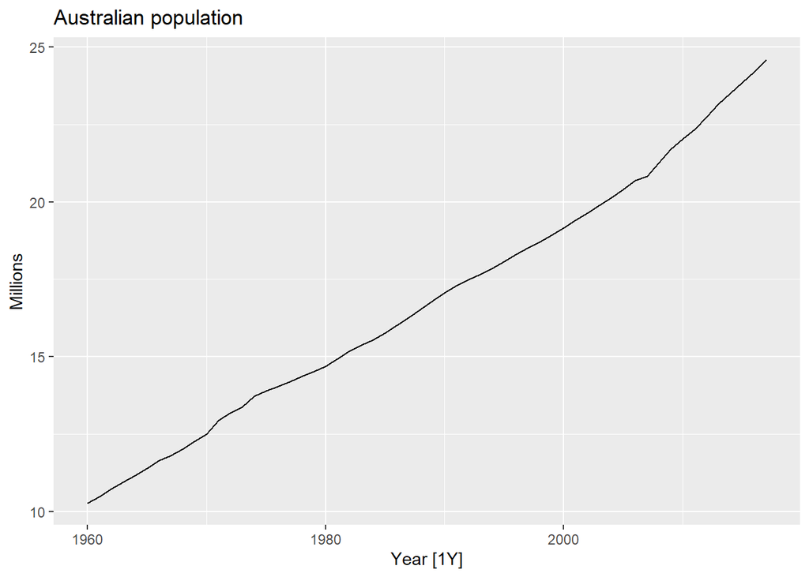

```r
aus_economy <- global_economy %>%
  filter(Code == "AUS") %>%
  mutate(Pop = Population / 1e6)
autoplot(aus_economy, Pop) +
  labs(y = "Millions", title = "Australian population")
```

Clearly, this is trended data. Trended exponential smoothing is therefore sensible.

Fitting Holt’s Method to a time series implies the following process:

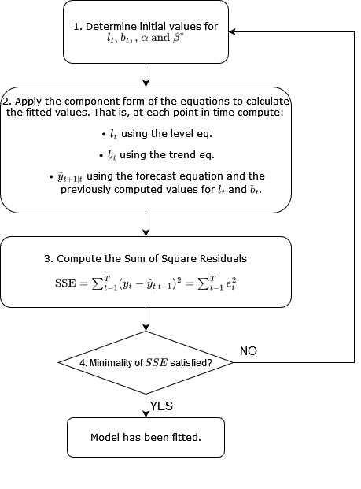

As an example, the table below shows steps 1 and 2 assuming initial estimated values $\hat{\alpha} = 0.9999$, $\hat{\beta^*} = 0.3267$, $l_t = 10.05$ and $b_t = 0.22$. The table also extends ten steps beyond the training data, generating the corresponding forecasts, based on the latest fitted values of the level, the slope and the smoothing parameters:

| Year | Time | Observation | Level | Slope | Forecast |
| --- | --- | --- | --- | --- | --- |
|  | $t$ | $y_t$ | $l_t$ |  | $\hat{y}_{t+1\|t}$ |
| 1959 | 0 |  | 10.05 | 0.22 |  |
| 1960 | 1 | 10.28 | 10.28 | 0.22 | 10.28 |
| 1961 | 2 | 10.48 | 10.48 | 0.22 | 10.50 |
| 1962 | 3 | 10.74 | 10.74 | 0.23 | 10.70 |
| 1963 | 4 | 10.95 | 10.95 | 0.22 | 10.97 |
| 1964 | 5 | 11.17 | 11.17 | 0.22 | 11.17 |
| 1965 | 6 | 11.39 | 11.39 | 0.22 | 11.39 |
| 1966 | 7 | 11.65 | 11.65 | 0.23 | 11.61 |
|  | $\vdots$ | $\vdots$ | $\vdots$ | $\vdots$ | $\vdots$ |
| 2014 | 55 | 23.50 | 23.50 | 0.37 | 23.52 |
| 2015 | 56 | 23.85 | 23.85 | 0.36 | 23.87 |
| 2016 | 57 | 24.21 | 24.21 | 0.36 | 24.21 |
| 2017 | 58 | 24.60 | 24.60 | 0.37 | 24.57 |
|  | $h$ |  |  |  | $\hat{y}_{T+h\|T}$ |
| 2018 | 1 |  |  |  | 24.97 |
| 2019 | 2 |  |  |  | 25.34 |
| 2020 | 3 |  |  |  | 25.71 |
| 2021 | 4 |  |  |  | 26.07 |
| 2022 | 5 |  |  |  | 26.44 |
| 2023 | 6 |  |  |  | 26.81 |
| 2024 | 7 |  |  |  | 27.18 |
| 2025 | 8 |  |  |  | 27.55 |
| 2026 | 9 |  |  |  | 27.92 |
| 2027 | 10 |  |  |  | 28.29 |

### Homework 1: reproduce this table in excel (template given by the professor)

The `fable` library performs all the fitting automatically using the following commands

```r
fit <- aus_economy %>%
  model(
    AAN = ETS(Pop ~ error("A") + trend("A") + season("N"))
  )
```

Remember the output is a `mable` or `model table`. In other words, a table object containing the model objects we fitted (in this case only one model)

```r
fit
```

```
# A mable: 1 x 2
# Key:     Country [1]
  Country            AAN
  <fct>          <model>
1 Australia <ETS(A,A,N)>
```

As always, we can check the values of the parameters using the function `tidy`

```r
tidy(fit)
```

```
# A tibble: 4 x 4
  Country   .model term  estimate
  <fct>     <chr>  <chr>    <dbl>
1 Australia AAN    alpha    1.00
2 Australia AAN    beta     0.327
3 Australia AAN    l[0]    10.1
4 Australia AAN    b[0]     0.222
```

We may also compute the sum of square residuals using `augment()`

```r
resid <- fit %>% augment() %>% pull(.innov)
SSE <- sum(resid^2)
SSE
```

```
[1] 0.2231852
```

We may generate forecasts as usual using `forecast()` on the fitted object:

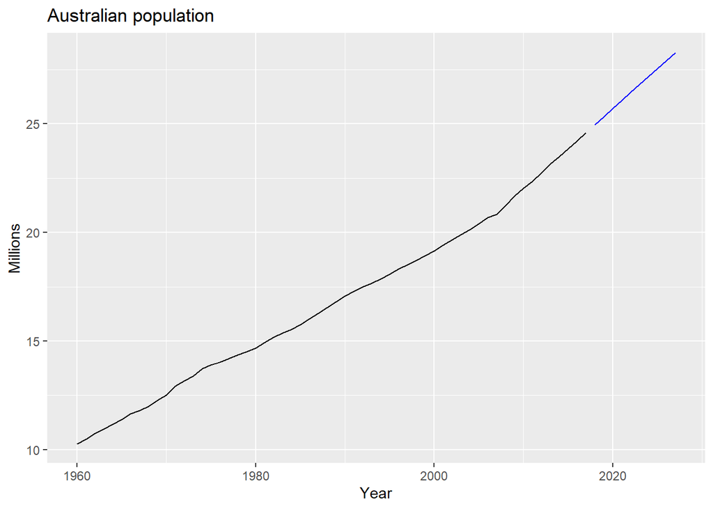

```r
fc <- fit %>% forecast(h = 10)

fc %>% autoplot(aus_economy, level = NULL) +
  labs(title = "Australian population",
       y = "Millions") +
  guides(colour = guide_legend(title = "Forecast"))
```

As expected, the **h-step ahead forecast** is equal to the **last estimated level** plus **h times the last estimated trend value.** As such, the forecasts are a **linear function of h**.

# Damped trend methods

- **Holt’s linear method** $\rightarrow$ constant trend
  - Problematic for longer forecasts horizons (forecasts too high)
- **Dampening parameter** $\rightarrow$ dampens the trend line to a flat line at some point in the future.
  - Very popular method, proven to be quite successful
  - **Additional parameter** on top of those included in Holt’s method $0<\phi<1$
  - For $\phi = 1$ the method is equivalent to Holt’s method
  - For $0 < \phi < 1$ the trend is dampened and the forecasts approach a constant value some time into the future. Specifically the value is:
    - $\ell_T+\phi b_T/(1-\phi)$ as $h \rightarrow \infty$

The reason for the above value is that the dampening term is actually a geometric progression of ratio $\phi$:

$$\begin{align*}
\text{Forecast equation dampened method} && \hat{y}_{t+h|t} &= \ell_{t} + (\phi+\phi^2 + \dots + \phi^{h})b_{t} \\
\text{Forecast equation Holt's method} && \hat{y}_{t+h|t} &= \ell_{t} + hb_{t} \\
\end{align*}$$

As you can see the $h$ factor has been replaced by the following geometric progression:

$$\begin{align*}
(\phi+\phi^2 + \dots + \phi^{h})
\end{align*}$$

Since the ratio $\phi$ is smaller than 1, the geometric progression converges and its sum amounts to $\ell_T+\phi b_T/(1-\phi)$ as $h \rightarrow \infty$

Usual values for $\phi$

- Rarely less than 0.8 (very strong effect for smaller values)
- Rarely greater than 0.98 (otherwise very similar to undamped model)

## Example: Australian population continued

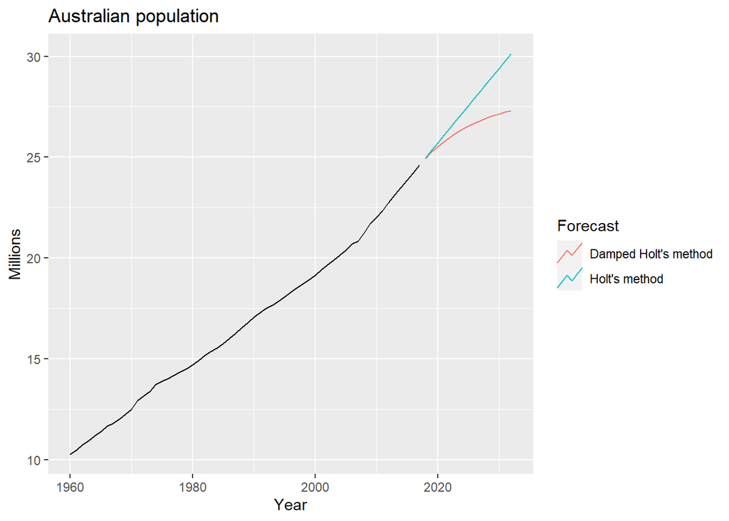

```r
aus_economy %>%
  model(
    `Holt's method` = ETS(Pop ~ error("A") +
                       trend("A") + season("N")),
    `Damped Holt's method` = ETS(Pop ~ error("A") +
                       trend("Ad", phi = 0.9) + season("N")) # Damping parameter set to 0.9
  ) %>%

  forecast(h = 15) %>%

  autoplot(aus_economy, level = NULL) +
  labs(title = "Australian population",
       y = "Millions") +
  guides(colour = guide_legend(title = "Forecast"))
```

**Specifying a grid of values for the value of phi**:

```r
fit_dampened2 <-
aus_economy %>%
    model(
      `Holt's method` = ETS(Pop ~ error("A") +
                         trend("A") + season("N")),
      `Damped Holt's method` = ETS(Pop ~ error("A") +
                                         trend("Ad", phi = NULL, phi_range=c(0.8, 0.95)) +
                                         season("N"))
                                  )
```

```r
tidy(fit_dampened2)
```

```
# A tibble: 9 x 4
  Country   .model               term  estimate
  <fct>     <chr>                <chr>    <dbl>
1 Australia Holt's method        alpha    1.00
2 Australia Holt's method        beta     0.327
3 Australia Holt's method        l[0]    10.1
4 Australia Holt's method        b[0]     0.222
5 Australia Damped Holt's method alpha    0.533
6 Australia Damped Holt's method beta     0.533
7 Australia Damped Holt's method phi      0.950
8 Australia Damped Holt's method l[0]     9.96
9 Australia Damped Holt's method b[0]     0.207
```

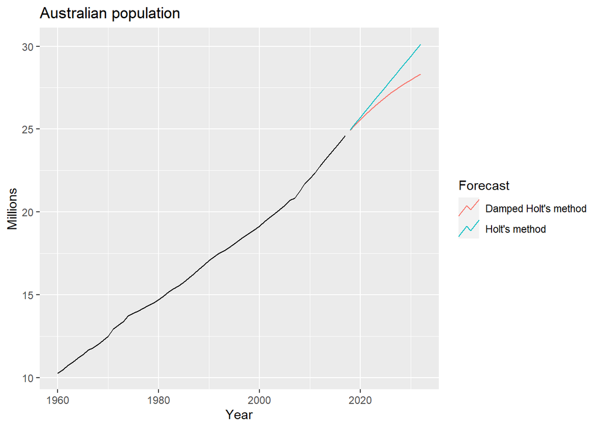

```r
fc_dampened2 <- fit_dampened2 %>% forecast(h = 15)

fc_dampened2 %>%
  autoplot(aus_economy, level = NULL) +
  labs(title = "Australian population",
       y = "Millions") +
  guides(colour = guide_legend(title = "Forecast"))
```

**Fitting a damped model without specifying a range or a specific value for phi**

```r
fit_dampened3 <-
aus_economy %>%
    model(
      `Holt's method` = ETS(Pop ~ error("A") +
                         trend("A") + season("N")),
      `Damped Holt's method` = ETS(Pop ~ error("A") +
                                         trend("Ad") +
                                         season("N"))
                                  )
```

```r
tidy(fit_dampened3)
```

```
# A tibble: 9 x 4
  Country   .model               term  estimate
  <fct>     <chr>                <chr>    <dbl>
1 Australia Holt's method        alpha    1.00
2 Australia Holt's method        beta     0.327
3 Australia Holt's method        l[0]    10.1
4 Australia Holt's method        b[0]     0.222
5 Australia Damped Holt's method alpha    0.999
6 Australia Damped Holt's method beta     0.427
7 Australia Damped Holt's method phi      0.980
8 Australia Damped Holt's method l[0]    10.0
9 Australia Damped Holt's method b[0]     0.248
```

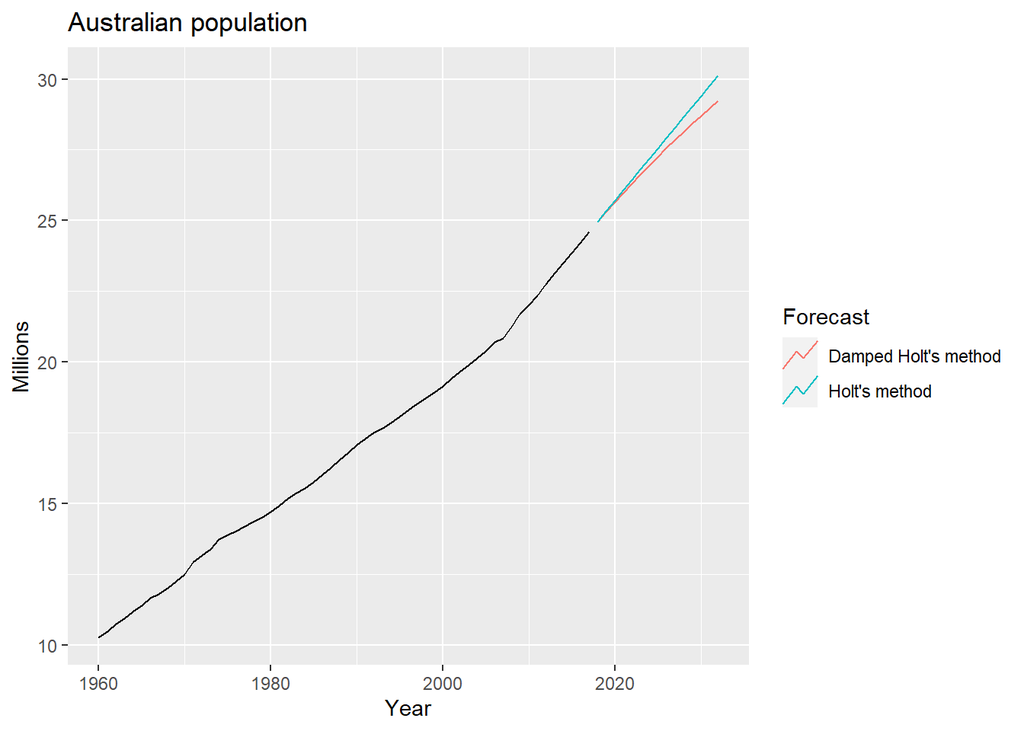

```r
fc_dampened3 <- fit_dampened3 %>% forecast(h = 15)

fc_dampened3 %>%
  autoplot(aus_economy, level = NULL) +
  labs(title = "Australian population",
       y = "Millions") +
  guides(colour = guide_legend(title = "Forecast"))
```

## Example: Internet usage

Comparison of forecasting performance for three exponential smoothing methods considered so far for forecasting the number of users connected to the internet via a server. Data observed over 100 minutes. Type `WWWusage` to find out more details aboout the dataset (loaded along the fpp3 package).

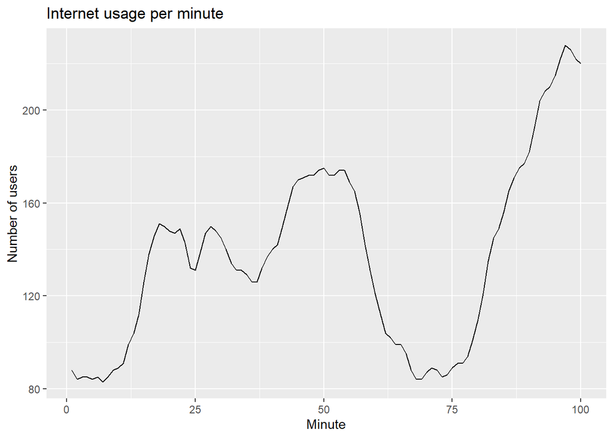

```r
# Convert time series object to tsibble object for compatibility with fable methods and tools
www_usage <- as_tsibble(WWWusage)

# Plot the data
www_usage %>%
  autoplot(value) +
  labs(x="Minute", y="Number of users",
       title = "Internet usage per minute")
```

To validate the results we will use **time series cross validation**. Please **go over this very important concept if you have forgotten about it**. We will go step by step to review the process:

1. Create the different datasets used for cross validation using `stretch_tsibble()`. Smallest dataset set to 10 observations.

```r
www_usage_cv <- www_usage %>%
                stretch_tsibble(.init = 10)

# Examine the table created
www_usage_cv
```

```
# A tsibble: 5,005 x 3 [1]
# Key:       .id [91]
   index value   .id
   <dbl> <dbl> <int>
 1     1    88     1
 2     2    84     1
 3     3    85     1
 4     4    85     1
 5     5    84     1
 6     6    85     1
 7     7    83     1
 8     8    85     1
 9     9    88     1
10    10    89     1
# ... with 4,995 more rows
```

```r
# Examine the number of datasets created
www_usage_cv %>% pull(.id) %>% max()
```

```
[1] 91
```

91 datasets have been created

2. Fit the models to be compared to the datasets used for cross-validation:

```r
fit_cv <-
  www_usage_cv %>%
    model(
      SES = ETS(value ~ error("A") + trend("N") + season("N")),
      Holt = ETS(value ~ error("A") + trend("A") + season("N")),
      Damped = ETS(value ~ error("A") + trend("Ad") +
                     season("N"))
      )

fit_cv
```

```
# A mable: 91 x 4
# Key:     .id [91]
     .id          SES         Holt        Damped
   <int>      <model>      <model>       <model>
 1     1 <ETS(A,N,N)> <ETS(A,A,N)> <ETS(A,Ad,N)>
 2     2 <ETS(A,N,N)> <ETS(A,A,N)> <ETS(A,Ad,N)>
 3     3 <ETS(A,N,N)> <ETS(A,A,N)> <ETS(A,Ad,N)>
 4     4 <ETS(A,N,N)> <ETS(A,A,N)> <ETS(A,Ad,N)>
 5     5 <ETS(A,N,N)> <ETS(A,A,N)> <ETS(A,Ad,N)>
 6     6 <ETS(A,N,N)> <ETS(A,A,N)> <ETS(A,Ad,N)>
 7     7 <ETS(A,N,N)> <ETS(A,A,N)> <ETS(A,Ad,N)>
 8     8 <ETS(A,N,N)> <ETS(A,A,N)> <ETS(A,Ad,N)>
 9     9 <ETS(A,N,N)> <ETS(A,A,N)> <ETS(A,Ad,N)>
10    10 <ETS(A,N,N)> <ETS(A,A,N)> <ETS(A,Ad,N)>
# ... with 81 more rows
```

Recall that the output of this step is a `mable`, a model table containing all the model objects fitted to the different datasets. The number of models fitted are:

3 model types * 91 datasets = 273 models.

3. **Perform the forecasts**

```r
fit_cv %>% forecast(h=1) %>% accuracy(www_usage) %>% select(.model, MAE, RMSE)
```

```
# A tibble: 3 x 3
  .model   MAE  RMSE
  <chr>  <dbl> <dbl>
1 Damped  3.00  3.69
2 Holt    3.17  3.87
3 SES     4.81  6.05
```

```r
fit <- www_usage %>%
  model(
    Damped = ETS(value ~ error("A") + trend("Ad") +
                   season("N"))
  )

tidy(fit)
```

```
# A tibble: 5 x 3
  .model term  estimate
  <chr>  <chr>    <dbl>
1 Damped alpha   1.00
2 Damped beta    0.997
3 Damped phi     0.815
4 Damped l[0]   90.4
5 Damped b[0]   -0.0173
```

```r
fit %>% tidy()
```

```
# A tibble: 5 x 3
  .model term  estimate
  <chr>  <chr>    <dbl>
1 Damped alpha   1.00
2 Damped beta    0.997
3 Damped phi     0.815
4 Damped l[0]   90.4
5 Damped b[0]   -0.0173
```

**NOTE** sometimes **different accuracy measures will suggest different forecasting methods**. A decision is required as to **which forecasting method we prefer to use**.

- Think about the **primary dimensions of your forecasting task**: length of forecast horizon, size of test set, forecast error measures, frequency of data…
- Unlikely that one method will be better than all other in all dimensions. Therefore important to think about the task at hand.

Finally let us perform and depict forecasts:

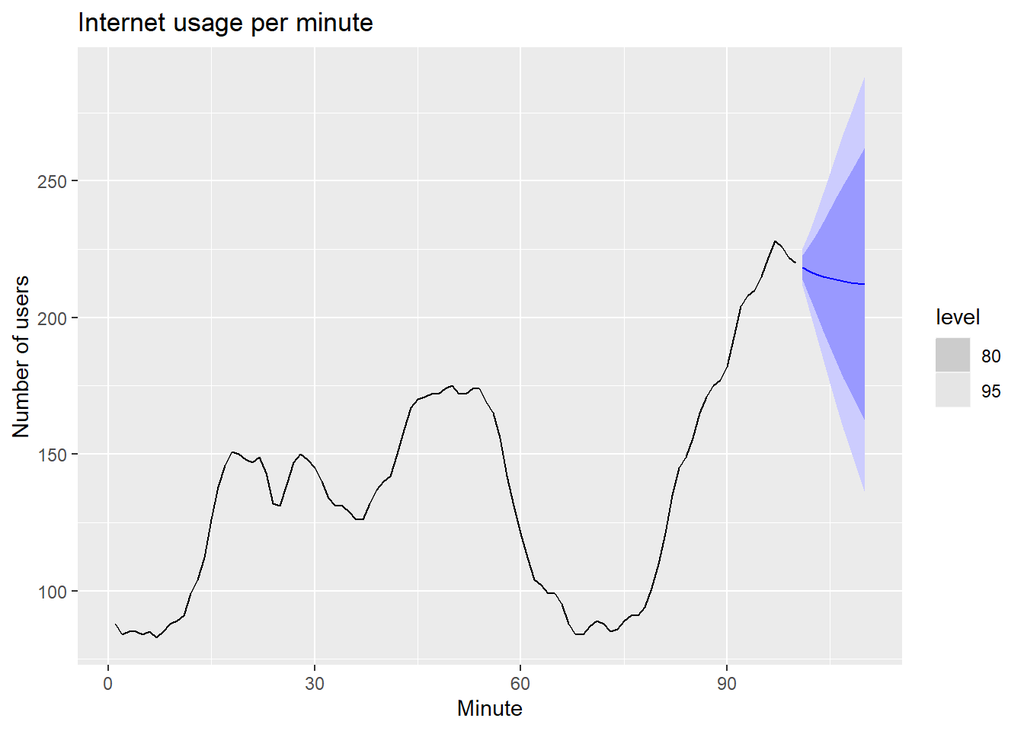

```r
fit %>%
  forecast(h = 10) %>%
  autoplot(www_usage) +
  labs(x="Minute", y="Number of users",
       title = "Internet usage per minute")
```